# Single Species Gopher Population Model

Elizabeth Hiroyasu

July 18, 2016

This gopher stage-structured population model explores the population dynamics of gophers in agricultural areas based on a simple, three-stage model. This represents the initial stages for exploring population growth and expansion of gopher populations and we hope to use this modeling exercise to provide information about how to better target management strategies for pest species.

Parameters and initial population sizes have been taken from literature estimates both of the growth and survival rates of the population and the densities of gopher populations for species Thomomys talpoides. For this model we used the ‘popbio’ package in R.

```r
library(popbio)
```

## Setting up the matrix

We directly filled population parameters into a 3x3 matrix, with a juvenile, subadult, and adult stage.

```r
stages = c("Juvenile", "SubAdult", "Adult")
```

The initial matrix looks as follows:

| Stage | Juvenile | SubAdult | Adult |
| --- | --- | --- | --- |
| Juvenile | 0 | f2 | f3 |
| SubAdult | p1 | 0 | 0 |
| Adult | 0 | p2 | p3 |

p21: probability of juvenile becoming a sub adult* p32: probability of a subadult becoming reproductive adult p33: probability of staying adult

f2: birth rate from subadults f3: birth rate from reproductive adults

*this term is unknown in gophers so we will use estimates from the vole population

To build the matrix, we use the following code:

```r
GopherMatrix = matrix(data=c(0,f2, f3, p1, 0, 0, 0, p2, p3),
              nrow=3, ncol=3, byrow=TRUE,
              dimnames=list(stages,stages))
```

Resulting in a matrix that looks like this:

| Stage | Juvenile | SubAdult | Adult |
| --- | --- | --- | --- |
| Juvenile | 0.00 | 2.535 | 7.775 |
| SubAdult | 0.69 | 0.00 | 0.00 |
| Adult | 0.00 | 0.468 | 0.449 |

## Projecting the population

Suppose we start with a population of zero juveniles, zero subadults, and seven adults.This is the average density of gophers in an alfalfa field per hectare.

To project the population to next year, we use matrix multiplication (denoted by the %*%) to multiply the transition matrix by the starting population

```r
N1 = GopherMatrix %*% N
```

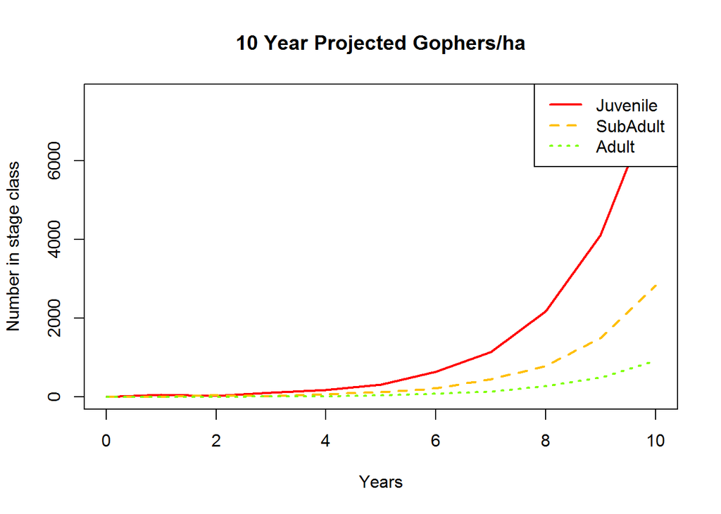

Adult population projection(without density dependence)

```
##        [,1]     [,2]      [,3]      [,4]      [,5]      [,6]      [,7]
##  [1,] 3.592 1.612808 20.809775 18.362034 47.426604  89.31632 154.73993
##  [2,] 2.245 1.008005 13.006109 11.476271 29.641628  55.82270  96.71245
##  [3,] 0.898 0.403202  5.202444  4.590509 11.856651  22.32908  38.68498
##  [4,] 4.041 1.814409 23.410997 20.657288 53.354930 100.48086 174.08242
##  [5,] 0.449 0.201601  2.601222  2.295254  5.928326  11.16454  19.34249
##  [6,] 1.796 0.806404 10.404887  9.181017 23.713302  44.65816  77.36996
##  [7,] 3.143 1.411207 18.208553 16.066780 41.498279  78.15178 135.39744
##  [8,] 4.490 2.016010 26.012218 22.952543 59.283255 111.64540 193.42491
##  [9,] 0.000 0.000000  0.000000  0.000000  0.000000   0.00000   0.00000
## [10,] 2.694 1.209606 15.607331 13.771526 35.569953  66.98724 116.05495
##            [,8]      [,9]     [,10]     [,11]
##  [1,] 307.53264 562.84604 1057.6167 1989.9688
##  [2,] 192.20790 351.77878  661.0105 1243.7305
##  [3,]  76.88316 140.71151  264.4042  497.4922
##  [4,] 345.97422 633.20180 1189.8188 2238.7149
##  [5,]  38.44158  70.35576  132.2021  248.7461
##  [6,] 153.76632 281.42302  528.8084  994.9844
##  [7,] 269.09106 492.49029  925.4147 1741.2227
##  [8,] 384.41580 703.55756 1322.0209 2487.4610
##  [9,]   0.00000   0.00000    0.0000    0.0000
## [10,] 230.64948 422.13453  793.2126 1492.4766
```

[figure not shown]

SubAdult population projection(without density dependence)

```
##       [,1]     [,2]      [,3]      [,4]      [,5]      [,6]      [,7]
##  [1,]    0 42.91800 19.270182  83.72233 145.34568 244.95064 508.66327
##  [2,]    0 26.82375 12.043864  52.32646  90.84105 153.09415 317.91454
##  [3,]    0 10.72950  4.817545  20.93058  36.33642  61.23766 127.16582
##  [4,]    0 48.28275 21.678955  94.18762 163.51389 275.56947 572.24618
##  [5,]    0  5.36475  2.408773  10.46529  18.16821  30.61883  63.58291
##  [6,]    0 21.45900  9.635091  41.86117  72.67284 122.47532 254.33163
##  [7,]    0 37.55325 16.861409  73.25704 127.17747 214.33181 445.08036
##  [8,]    0 53.64750 24.087727 104.65291 181.68210 306.18830 635.82909
##  [9,]    0  0.00000  0.000000   0.00000   0.00000   0.00000   0.00000
## [10,]    0 32.18850 14.452636  62.79175 109.00926 183.71298 381.49745
##            [,8]      [,9]     [,10]     [,11]
##  [1,]  907.6152 1719.8694 3237.3908 6027.8379
##  [2,]  567.2595 1074.9184 2023.3692 3767.3987
##  [3,]  226.9038  429.9673  809.3477 1506.9595
##  [4,] 1021.0670 1934.8531 3642.0646 6781.3176
##  [5,]  113.4519  214.9837  404.6738  753.4797
##  [6,]  453.8076  859.9347 1618.6954 3013.9189
##  [7,]  794.1633 1504.8857 2832.7169 5274.3581
##  [8,] 1134.5189 2149.8367 4046.7384 7534.7973
##  [9,]    0.0000    0.0000    0.0000    0.0000
## [10,]  680.7114 1289.9020 2428.0431 4520.8784
```

[figure not shown]

Juvenile population projection(without density dependence)

```
##         [,1]      [,2]      [,3]      [,4]      [,5]      [,6]      [,7]
##  [1,] 62.200 27.927800 121.33671 210.64591 355.00092 737.19314 1315.3843
##  [2,] 38.875 17.454875  75.83545 131.65369 221.87558 460.74571  822.1152
##  [3,] 15.550  6.981950  30.33418  52.66148  88.75023 184.29829  328.8461
##  [4,] 69.975 31.418775 136.50380 236.97665 399.37604 829.34229 1479.8073
##  [5,]  7.775  3.490975  15.16709  26.33074  44.37512  92.14914  164.4230
##  [6,] 31.100 13.963900  60.66836 105.32296 177.50046 368.59657  657.6921
##  [7,] 54.425 24.436825 106.16962 184.31517 310.62581 645.04400 1150.9612
##  [8,] 77.750 34.909750 151.67089 263.30739 443.75116 921.49143 1644.2303
##  [9,]  0.000  0.000000   0.00000   0.00000   0.00000   0.00000    0.0000
## [10,] 46.650 20.945850  91.00253 157.98443 266.25069 552.89486  986.5382
##            [,8]      [,9]     [,10]     [,11]
##  [1,] 2492.5643 4691.8707  8735.997 16429.756
##  [2,] 1557.8527 2932.4192  5459.998 10268.597
##  [3,]  623.1411 1172.9677  2183.999  4107.439
##  [4,] 2804.1349 5278.3545  9827.996 18483.475
##  [5,]  311.5705  586.4838  1092.000  2053.719
##  [6,] 1246.2822 2345.9353  4367.998  8214.878
##  [7,] 2180.9938 4105.3868  7643.997 14376.036
##  [8,] 3115.7054 5864.8383 10919.996 20537.195
##  [9,]    0.0000    0.0000     0.000     0.000
## [10,] 1869.4232 3518.9030  6551.998 12322.317
```

[figure not shown]

## Stable stage distribution

To determine the stable stage distribution, which will tell use the proportion of the population we can expect the population to stabilize around in each class. In other words, the population size may change, but the proportion of individuals in each class will have converged on a single point.

```r
gopher_projection$stable.stage
```

```
##   Juvenile   SubAdult      Adult
## 0.67040089 0.24843755 0.08116157
```

To determine the dominant eigenvalue, lambda, we can use the ‘lambda’ command, it is also given as part of the list of outputs from the pop.projection command. The dominany eigenvalue tells us the population growth rate of a projection matrix. If lambda is greater than one, the population will grow, if it less than one then the population will be declining, and if it is equal to one the population will be neither growing, nor declining.

```r
gopher_projection$lambda
```

```
## [1] 1.868355
```

## Calculating elasticities

Finally, we can calculate the elasticities of the projection matrix. The largest value will tell us which transition contributes most to the observed population trend.

```r
elasticity(GopherMatrix)
```

```
##           Juvenile  SubAdult      Adult
## Juvenile 0.0000000 0.1872774 0.18866418
## SubAdult 0.3759416 0.0000000 0.00000000
## Adult    0.0000000 0.1886642 0.05945271
```

## Population simulations

Now, if we want to simulate the population, the popbio package includes a function to carry out stochastic simulations.To conduct simulations, we can randomly draw numbers between the minimum and maximum values seen in the literature, for each matrix element.

```r
#creating vectors of matrix elements
p1Sim =runif(10, 0.59, 0.80)
p2Sim = runif(10, 0.357, 0.570)
p3Sim = runif(10, 0.25, 0.67)
f2Sim = runif(10, 2.4, 2.67)
f3Sim = runif(10, 5.35, 10.2)


#Creating a 10 matrix array and list for the stoch.projection function
GopherArray<-array(0, c(3,3,10))
GopherList<-list(NULL)
for  (i in 1:10){
  GopherArray[,,i]<-(matrix(data=c(0,f2Sim[i], f3Sim[i], p1Sim[i], 0, 0, 0, p2Sim[i],
                    p3Sim[i]), nrow=3,ncol=3, byrow = TRUE, dimnames =list(stages,stages)))
  GopherList[[i]]<- GopherArray[,,i]
  }
```

Running the simulations using the stochastic projection function in the popbio package:

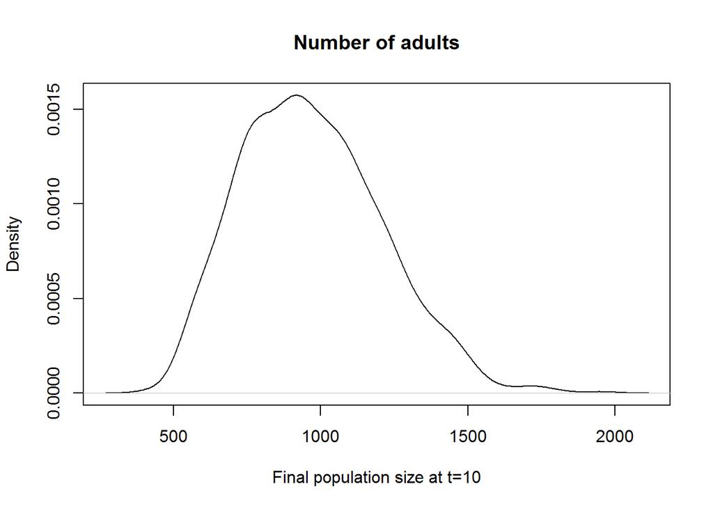

```r
gopher.ens<-stoch.projection(GopherList,N, tmax=10, nreps=1000)

plot(density(gopher.ens[,3]), xlab="Final population size at t=10",
     main="Number of adults")
abline(v=N[3], lty=3)
```

```r
#matplot(0:10, gopher.ens[,1])
```